# 2. Data inspection

Gerko Vink

This document is aimed at inspecting the data and detecting anomalies that may influence any data imputation and subsequent data analysis steps. The aim for this document is not to provide a fix if any peculiarities and/or anomalies are found.

# Packages used

For this document we use the following packages

```r
library(dplyr)    # Data manipulation
library(mice)     # Data imputation
library(magrittr) # Pipes
library(purrr)    # Functional programming
library(haven)    # Import data
library(DT)       # Interactive tables
```

# Read in the data file

We read in the workspace `1. Data import and preparation.Rdata` from the `\Workspaces\` directory in the project’s root. This workspace has been generated by the document `1. Data import and preparation.Rmd`.

```r
load("Workspaces/1. Data import and preparation.Rdata")
```

# Dimensions of the data

To obtain the dimensionality of the data:

```r
dim(NSRI_df)
```

```
## [1] 6813  112
```

We can see that the object `NSRI_df` has 6813 rows and 112 columns.

# Are the row ID’s unique?

```r
NSRI_df %$% unique(ID) %>% length
```

```
## [1] 6813
```

```r
NSRI_df %$% length(ID)
```

```
## [1] 6813
```

The length of the vector of unique `ID`’s is equal to the length of the vector `ID`. There are no duplicate `ID`’s: every `ID` is unique.

# Are there any duplicate rows

```r
(duplicated(NSRI_df) | duplicated(NSRI_df, fromLast = TRUE)) %>%
  any()
```

```
## [1] FALSE
```

There are no duplicate rows in the data.

# Measurement level of the columns

```r
NSRI_df %>% map(class) %>% unlist
```

```
##          ID FinishDate1 FinishDate2         IC1         IC2          D1
## "character"   "POSIXct"    "POSIXt"    "factor"    "factor"    "factor"
##          D2          D3          D4          D5           V         F19
##    "factor"    "factor"    "factor"    "factor"    "factor"   "numeric"
##         F20         F21         F22         F23         F24         F25
##   "numeric"   "numeric"   "numeric"   "numeric"   "numeric"   "numeric"
##         F26         F27         F28         F29         F30         F31
##   "numeric"   "numeric"   "numeric"   "numeric"   "numeric"   "numeric"
##         F32         F33         F34         F35         F36         F37
##   "numeric"   "numeric"   "numeric"   "numeric"   "numeric"   "numeric"
##         F38         F39         F40         F41         F42         F43
##   "numeric"   "numeric"   "numeric"   "numeric"   "numeric"   "numeric"
##         F44         F45         F46         F47         F48         F49
##   "numeric"   "numeric"   "numeric"   "numeric"   "numeric"   "numeric"
##         F50         F51          F1          F2          F3          F4
##   "numeric"   "numeric"   "numeric"   "numeric"   "numeric"   "numeric"
##          F5          F6          F7          F8          F9         F10
##   "numeric"   "numeric"   "numeric"   "numeric"   "numeric"   "numeric"
##         F11         F12         F13         F14         F15         F16
##   "numeric"   "numeric"   "numeric"   "numeric"   "numeric"   "numeric"
##         F17         F18         F52         F53         F54         F55
##   "numeric"   "numeric"   "numeric"   "numeric"   "numeric"   "numeric"
##         F56         F57         F58         F59         F60         F61
##   "numeric"   "numeric"   "numeric"   "numeric"   "numeric"   "numeric"
##         F62         F63         F64         F65         F66         F67
##   "numeric"   "numeric"   "numeric"   "numeric"   "numeric"   "numeric"
##         F68         F69         F70         F71         F72         F73
##   "numeric"   "numeric"   "numeric"   "numeric"   "numeric"   "numeric"
##         F74         F75         RP1         RP2         RP3         RP4
##   "numeric"   "numeric"   "numeric"   "numeric"   "numeric"   "numeric"
##         RP5         RP6         RP7         RP8         RP9        RP10
##   "numeric"   "numeric"   "numeric"   "numeric"   "numeric"   "numeric"
##        RP11        RP12        RP13        RP14        RP15        RP16
##   "numeric"   "numeric"   "numeric"   "numeric"   "numeric"   "numeric"
##        RP17        RP18        RP19        RP20        RP21        RP22
##   "numeric"   "numeric"   "numeric"   "numeric"   "numeric"   "numeric"
##     RRtest1     RRtest2         RR1         RR2       Group
##    "factor"    "factor"    "factor"    "factor"    "factor"
```

# Distribution of the cases over `V`

To inspect how the cases are distributed over column `V` - the indicator for the planned missingness - we use

```r
NSRI_df %$%
  table(V)
```

```
## V
## Version 1 Version 2 Version 3
##      2295      2243      2275
```

We can see that the randomization resulted in approximately equal group sizes. This may indicate that randomization was succesful. To inspect the proportional distribution of the cases over `V`:

```r
NSRI_df %$%
  table(V) %>%
  prop.table %>%
  round(digits = 3)
```

```
## V
## Version 1 Version 2 Version 3
##     0.337     0.329     0.334
```

The versions `V` over the cases are approximately distributed in thirds.

# Missingness inspection

## Number of missing values

To inspect the number of missing values in the data we first calculate the total number of cells:

```r
ncells <- nrow(NSRI_df) * ncol(NSRI_df)
ncells
```

```
## [1] 763056
```

Out of 763056 cells, a total of

```r
nmis <- is.na(NSRI_df) %>% sum
nmis
```

```
## [1] 178067
```

are missing, which translates to

```r
nmis / ncells
```

```
## [1] 0.2333603
```

23.3 percent of cells being unobserved in the data.

## Missings per column

```r
apply(NSRI_df, 2, function(x) sum(is.na(x)))
```

```
##         ID FinishDate        IC1        IC2         D1         D2         D3
##          0          0          0       6813          0          0          0
##         D4         D5          V        F19        F20        F21        F22
##          0          0          0       2243       2295       2275       2275
##        F23        F24        F25        F26        F27        F28        F29
##       2275       2243       2243       2295       2295       2243       2243
##        F30        F31        F32        F33        F34        F35        F36
##       2295       2295       2275       2275       2243       2243       2295
##        F37        F38        F39        F40        F41        F42        F43
##       2295       2275       2275       2275       2275       2295       2243
##        F44        F45        F46        F47        F48        F49        F50
##       2243       2295       2275       2275       2243       2243       2295
##        F51         F1         F2         F3         F4         F5         F6
##       2295       2275       2275       2275       2243       2243       2243
##         F7         F8         F9        F10        F11        F12        F13
##       2295       2295       2295       2275       2275       2275       2243
##        F14        F15        F16        F17        F18        F52        F53
##       2243       2243       2295       2295       2295       2295       2295
##        F54        F55        F56        F57        F58        F59        F60
##       2275       2275       2243       2243       2243       2243       2295
##        F61        F62        F63        F64        F65        F66        F67
##       2295       2275       2275       2275       2275       2243       2243
##        F68        F69        F70        F71        F72        F73        F74
##       2295       2295       2295       2295       2275       2275       2243
##        F75        RP1        RP2        RP3        RP4        RP5        RP6
##       2243          0          0          0          0          0          0
##        RP7        RP8        RP9       RP10       RP11       RP12       RP13
##          0          0          0          0          0          0          0
##       RP14       RP15       RP16       RP17       RP18       RP19       RP20
##          0          0          0          0          0          0          0
##       RP21       RP22    RRtest1    RRtest2        RR1        RR2      Group
##          0          0        481        448          0          0          0
```

## Completely unobserved columns

```r
which <- apply(NSRI_df, 2, function(x) all(is.na(x)))
names(NSRI_df)[which]
```

```
## [1] "IC2"
```

Column `IC2` is completely unobserved. Missingness is only observed on items where missingness is expected due to the questionnaire design.

## Missing data pattern

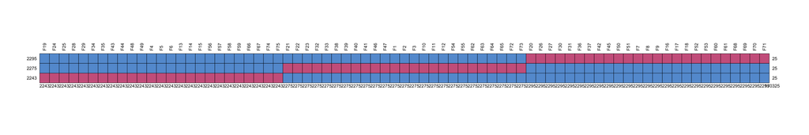

```
##       F19  F24  F25  F28  F29  F34  F35  F43  F44  F48  F49   F4   F5   F6  F13
## 2295    1    1    1    1    1    1    1    1    1    1    1    1    1    1    1
## 2275    1    1    1    1    1    1    1    1    1    1    1    1    1    1    1
## 2243    0    0    0    0    0    0    0    0    0    0    0    0    0    0    0
##      2243 2243 2243 2243 2243 2243 2243 2243 2243 2243 2243 2243 2243 2243 2243
##       F14  F15  F56  F57  F58  F59  F66  F67  F74  F75  F21  F22  F23  F32  F33
## 2295    1    1    1    1    1    1    1    1    1    1    1    1    1    1    1
## 2275    1    1    1    1    1    1    1    1    1    1    0    0    0    0    0
## 2243    0    0    0    0    0    0    0    0    0    0    1    1    1    1    1
##      2243 2243 2243 2243 2243 2243 2243 2243 2243 2243 2275 2275 2275 2275 2275
##       F38  F39  F40  F41  F46  F47   F1   F2   F3  F10  F11  F12  F54  F55  F62
## 2295    1    1    1    1    1    1    1    1    1    1    1    1    1    1    1
## 2275    0    0    0    0    0    0    0    0    0    0    0    0    0    0    0
## 2243    1    1    1    1    1    1    1    1    1    1    1    1    1    1    1
##      2275 2275 2275 2275 2275 2275 2275 2275 2275 2275 2275 2275 2275 2275 2275
##       F63  F64  F65  F72  F73  F20  F26  F27  F30  F31  F36  F37  F42  F45  F50
## 2295    1    1    1    1    1    0    0    0    0    0    0    0    0    0    0
## 2275    0    0    0    0    0    1    1    1    1    1    1    1    1    1    1
## 2243    1    1    1    1    1    1    1    1    1    1    1    1    1    1    1
##      2275 2275 2275 2275 2275 2295 2295 2295 2295 2295 2295 2295 2295 2295 2295
##       F51   F7   F8   F9  F16  F17  F18  F52  F53  F60  F61  F68  F69  F70  F71
## 2295    0    0    0    0    0    0    0    0    0    0    0    0    0    0    0
## 2275    1    1    1    1    1    1    1    1    1    1    1    1    1    1    1
## 2243    1    1    1    1    1    1    1    1    1    1    1    1    1    1    1
##      2295 2295 2295 2295 2295 2295 2295 2295 2295 2295 2295 2295 2295 2295 2295
##
## 2295     25
## 2275     25
## 2243     25
##      170325
```

```r
md.pattern(NSRI_df[, 11:85], rotate.names = TRUE)
```

The missing data pattern displays 3 distinct patterns; each with 50 columns observed and 25 columns unobserved. This is conform the expected planned missingness.

# Demographic comparisons

## Version

To quickly identify if there are differences in the medians between the randomly assigned versions `V`.

```r
NSRI_df %>%
  group_by(V) %>%
  summarise_if(is.numeric, median, na.rm = TRUE) %>%
  datatable(options = list(scrollX = TRUE))
```

|  | V | F19 | F20 | F21 | F22 | F23 | F24 | F25 | F26 | F27 | F28 | F29 | F30 | F31 | F32 | F33 | F34 | F35 | F36 | F37 | F38 | F39 | F40 | F41 | F42 | F43 | F44 | F45 | F46 | … |
| --- | --- | --- | --- | --- | --- | --- | --- | --- | --- | --- | --- | --- | --- | --- | --- | --- | --- | --- | --- | --- | --- | --- | --- | --- | --- | --- | --- | --- | --- | --- |
| 1 | Version 1 | 3 |  | 5 | 6 | 4 | 3 | 3 |  |  | 3 | 4 |  |  | 3 | 6 | 4 | 4 |  |  | 4 | 5 | 5 | 4 |  | 4 | 5 |  | 4 | … |
| 2 | Version 2 |  | 5 | 5 | 6 | 4 |  |  | 4 | 2 |  |  | 6 | 6 | 3 | 6 |  |  | 3 | 4 | 3 | 5 | 5 | 4 | 3 |  |  | 5 | 4 | … |
| 3 | Version 3 | 3 | 5 |  |  |  | 4 | 4 | 4 | 2 | 3 | 4 | 6 | 6 |  |  | 4 | 4 | 4 | 4 |  |  |  |  | 3 | 4 | 5 | 4 |  | … |

## Research involvement

To quickly identify if there are differences in the medians for groups that do or do not spend more than 8 hours on research a week `D1`.

```r
NSRI_df %$% table(D1)
```

```
## D1
##  Yes   No
## 6813    0
```

Column `D1` is constant.

## Academic field

To quickly identify if there are differences in the medians between the academic fields `D2`.

```r
NSRI_df %$% table(D2)
```

```
## D2
##   Social and Behavioral Sciences              Arts and Humanities
##                             1965                              636
## Engineering and Natural Sciences     Biomedical and Life Sciences
##                             1465                             2747
```

```r
NSRI_df %>%
  na_if(8) %>% # Exclude the not applicable's
  group_by(D2) %>%
  summarise_if(is.numeric, median, na.rm = TRUE) %>%
  datatable(options = list(scrollX = TRUE))
```

|  | D2 | F19 | F20 | F21 | F22 | F23 | F24 | F25 | F26 | F27 | F28 | F29 | F30 | F31 | F32 | F33 | F34 | F35 | F36 | F37 | F38 | F39 | F40 | F41 | F42 | F43 | F44 | F45 | F46 | … |
| --- | --- | --- | --- | --- | --- | --- | --- | --- | --- | --- | --- | --- | --- | --- | --- | --- | --- | --- | --- | --- | --- | --- | --- | --- | --- | --- | --- | --- | --- | --- |
| 1 | Social and Behavioral Sciences | 3 | 5 | 5 | 6 | 4 | 4 | 4 | 4 | 2 | 3 | 3 | 5 | 5 | 4 | 6 | 4 | 4 | 3 | 4 | 4 | 5 | 5 | 3 | 3 | 4 | 5 | 4 | 4 | … |
| 2 | Arts and Humanities | 3 | 5 | 5 | 6 | 4 | 4 | 4 | 5 | 2 | 3 | 3 | 6 | 5 | 4 | 6 | 4 | 4 | 3 | 3 | 3 | 4 | 4 | 3 | 3 | 4 | 4 | 3 | 3 | … |
| 3 | Engineering and Natural Sciences | 3 | 5 | 5 | 6 | 4 | 4 | 4 | 4 | 2 | 3 | 4 | 6 | 6 | 3 | 6 | 4 | 4 | 3 | 4 | 3 | 4 | 5 | 4 | 3 | 4 | 5 | 5 | 4 | … |
| 4 | Biomedical and Life Sciences | 3 | 5 | 5 | 5 | 4 | 3.5 | 3 | 4 | 2 | 3 | 4 | 6 | 6 | 2 | 6 | 4 | 5 | 4 | 4 | 4 | 5 | 5 | 4 | 3 | 5 | 5 | 5 | 4 | … |

## Academic rank

To quickly identify if there are differences in the medians between the rank `D3`.

```r
NSRI_df %$% table(D3)
```

```
## D3
##                                                          PhD student or junior researcher
##                                                                                      2013
## Postdoctoral researcher, Assistant Professor, Physician Researcher or Lecturer Researcher
##                                                                                      2733
##                                                     Associate Professor or Full Professor
##                                                                                      2067
##                                                                         None of the above
##                                                                                         0
```

There are no observations for `none of the above`. Let’s refactor the corresponding column to avoid redundant comparisons later on.

```r
NSRI_df %<>% mutate(D3 = factor(D3))
```

```r
NSRI_df %>%
  na_if(8) %>% # Exclude the not applicable's
  group_by(D3) %>%
  summarise_if(is.numeric, median, na.rm = TRUE) %>%
  datatable(options = list(scrollX = TRUE))
```

|  | D3 | F19 | F20 | F21 | F22 | F23 | F24 | F25 | F26 | F27 | F28 | F29 | F30 | F31 | F32 | F33 | F34 | F35 | F36 | F37 | F38 | F39 | F40 | F41 | F42 | F43 | F44 | F45 | F46 | … |
| --- | --- | --- | --- | --- | --- | --- | --- | --- | --- | --- | --- | --- | --- | --- | --- | --- | --- | --- | --- | --- | --- | --- | --- | --- | --- | --- | --- | --- | --- | --- |
| 1 | PhD student or junior researcher | 4 | 4 | 4 | 6 | 4 | 3 | 4 | 4 | 2 | 4 | 4 | 4 | 4 | 4 | 5 | 5 | 5 | 4 | 4 | 4 | 5 | 5 | 3 | 2 | 4 | 5 | 5 | 5 | … |
| 2 | Postdoctoral researcher, Assistant Professor, Physician Researcher or Lecturer Researcher | 3 | 5 | 5 | 6 | 5 | 4 | 4 | 5 | 2 | 2 | 5 | 6 | 6 | 3 | 6 | 4 | 4 | 4 | 4 | 4 | 5 | 5 | 4 | 3 | 5 | 5 | 4 | 4 | … |
| 3 | Associate Professor or Full Professor | 3 | 5 | 5 | 5 | 3 | 4 | 3 | 4 | 1 | 2 | 2 | 6 | 6 | 3 | 6 | 3 | 4 | 3 | 3 | 3 | 4 | 5 | 4 | 3 | 5 | 5 | 4 | 3 | … |

## Gender

```r
NSRI_df %$% table(D4)
```

```
## D4
##                          Female                            Male
##                            3008                            3689
## Other / Do not wish to disclose
##                             116
```

```r
NSRI_df %>%
  na_if(8) %>% # Exclude the not applicable's
  group_by(D4) %>%
  summarise_if(is.numeric, median, na.rm = TRUE) %>%
  datatable(options = list(scrollX = TRUE))
```

|  | D4 | F19 | F20 | F21 | F22 | F23 | F24 | F25 | F26 | F27 | F28 | F29 | F30 | F31 | F32 | F33 | F34 | F35 | F36 | F37 | F38 | F39 | F40 | F41 | F42 | F43 | F44 | F45 | F46 | … |
| --- | --- | --- | --- | --- | --- | --- | --- | --- | --- | --- | --- | --- | --- | --- | --- | --- | --- | --- | --- | --- | --- | --- | --- | --- | --- | --- | --- | --- | --- | --- |
| 1 | Female | 3 | 5 | 5 | 6 | 5 | 4 | 4 | 4 | 2 | 3 | 4 | 6 | 5 | 3 | 6 | 4 | 5 | 4 | 4 | 4 | 5 | 5 | 4 | 3 | 4 | 5 | 4 | 4 | … |
| 2 | Male | 3 | 5 | 5 | 5 | 4 | 4 | 3 | 4 | 2 | 3 | 3 | 6 | 5 | 3 | 6 | 4 | 4 | 3 | 4 | 3 | 4 | 5 | 4 | 3 | 4 | 5 | 4 | 4 | … |
| 3 | Other / Do not wish to disclose | 2 | 5 | 5 | 7 | 5 | 4 | 5 | 5 | 2 | 2 | 4.5 | 7 | 6 | 3 | 7 | 3 | 4 | 3 | 3 | 3 | 5 | 4 | 4.5 | 3 | 5 | 4 | 4 | 4 | … |

## Engagement

```r
NSRI_df %$% table(D5)
```

```
## D5
##  Yes   No
## 6083  730
```

```r
NSRI_df %>%
  na_if(8) %>% # Exclude the not applicable's
  group_by(D5) %>%
  summarise_if(is.numeric, median, na.rm = TRUE) %>%
  datatable(options = list(scrollX = TRUE))
```

|  | D5 | F19 | F20 | F21 | F22 | F23 | F24 | F25 | F26 | F27 | F28 | F29 | F30 | F31 | F32 | F33 | F34 | F35 | F36 | F37 | F38 | F39 | F40 | F41 | F42 | F43 | F44 | F45 | F46 | … |
| --- | --- | --- | --- | --- | --- | --- | --- | --- | --- | --- | --- | --- | --- | --- | --- | --- | --- | --- | --- | --- | --- | --- | --- | --- | --- | --- | --- | --- | --- | --- |
| 1 | Yes | 3 | 5 | 5 | 6 | 4 | 4 | 4 | 4 | 2 | 3 | 4 | 6 | 5 | 3 | 6 | 4 | 4 | 4 | 4 | 4 | 5 | 5 | 4 | 3 | 4 | 5 | 5 | 4 | … |
| 2 | No | 3 | 5 | 5 | 6 | 4 | 4 | 4 | 4 | 2 | 3 | 3 | 6 | 5 | 4 | 5 | 4 | 4 | 3 | 3 | 3 | 4 | 5 | 3 | 3 | 4 | 5 | 4 | 3 | … |

# Demographic distribution over V

## V x Field D2

```r
NSRI_df %$%
  table(V, D2) %>%
  datatable
```

|  | V | D2 | Freq |
| --- | --- | --- | --- |
| Version 1 | Version 1 | Social and Behavioral Sciences | 673 |
| Version 2 | Version 2 | Social and Behavioral Sciences | 642 |
| Version 3 | Version 3 | Social and Behavioral Sciences | 650 |
| Version 1 | Version 1 | Arts and Humanities | 215 |
| Version 2 | Version 2 | Arts and Humanities | 208 |
| Version 3 | Version 3 | Arts and Humanities | 213 |
| Version 1 | Version 1 | Engineering and Natural Sciences | 478 |
| Version 2 | Version 2 | Engineering and Natural Sciences | 486 |
| Version 3 | Version 3 | Engineering and Natural Sciences | 501 |
| Version 1 | Version 1 | Biomedical and Life Sciences | 929 |

[output cut: 2 more lines]

## V x Rank D3

```r
NSRI_df %$%
  table(V, D3) %>%
  datatable
```

|  | V | D3 | Freq |
| --- | --- | --- | --- |
| Version 1 | Version 1 | PhD student or junior researcher | 646 |
| Version 2 | Version 2 | PhD student or junior researcher | 680 |
| Version 3 | Version 3 | PhD student or junior researcher | 687 |
| Version 1 | Version 1 | Postdoctoral researcher, Assistant Professor, Physician Researcher or Lecturer Researcher | 959 |
| Version 2 | Version 2 | Postdoctoral researcher, Assistant Professor, Physician Researcher or Lecturer Researcher | 882 |
| Version 3 | Version 3 | Postdoctoral researcher, Assistant Professor, Physician Researcher or Lecturer Researcher | 892 |
| Version 1 | Version 1 | Associate Professor or Full Professor | 690 |
| Version 2 | Version 2 | Associate Professor or Full Professor | 681 |
| Version 3 | Version 3 | Associate Professor or Full Professor | 696 |

## V x Gender D4

```r
NSRI_df %$%
  table(V, D4) %>%
  datatable
```

|  | V | D4 | Freq |
| --- | --- | --- | --- |
| Version 1 | Version 1 | Female | 1032 |
| Version 2 | Version 2 | Female | 1003 |
| Version 3 | Version 3 | Female | 973 |
| Version 1 | Version 1 | Male | 1226 |
| Version 2 | Version 2 | Male | 1205 |
| Version 3 | Version 3 | Male | 1258 |
| Version 1 | Version 1 | Other / Do not wish to disclose | 37 |
| Version 2 | Version 2 | Other / Do not wish to disclose | 35 |
| Version 3 | Version 3 | Other / Do not wish to disclose | 44 |

## V x Engagement D5

```r
NSRI_df %$%
  table(V, D5) %>%
  datatable
```

|  | V | D5 | Freq |
| --- | --- | --- | --- |
| Version 1 | Version 1 | Yes | 2064 |
| Version 2 | Version 2 | Yes | 2021 |
| Version 3 | Version 3 | Yes | 1998 |
| Version 1 | Version 1 | No | 231 |
| Version 2 | Version 2 | No | 222 |
| Version 3 | Version 3 | No | 277 |

# Demographic distribution over Field

## Field D2 x Rank D3

```r
NSRI_df %$%
  table(D2, D3) %>%
  datatable
```

|  | D2 | D3 | Freq |
| --- | --- | --- | --- |
| Social and Behavioral Sciences | Social and Behavioral Sciences | PhD student or junior researcher | 535 |
| Arts and Humanities | Arts and Humanities | PhD student or junior researcher | 140 |
| Engineering and Natural Sciences | Engineering and Natural Sciences | PhD student or junior researcher | 429 |
| Biomedical and Life Sciences | Biomedical and Life Sciences | PhD student or junior researcher | 909 |
| Social and Behavioral Sciences | Social and Behavioral Sciences | Postdoctoral researcher, Assistant Professor, Physician Researcher or Lecturer Researcher | 839 |
| Arts and Humanities | Arts and Humanities | Postdoctoral researcher, Assistant Professor, Physician Researcher or Lecturer Researcher | 292 |
| Engineering and Natural Sciences | Engineering and Natural Sciences | Postdoctoral researcher, Assistant Professor, Physician Researcher or Lecturer Researcher | 603 |
| Biomedical and Life Sciences | Biomedical and Life Sciences | Postdoctoral researcher, Assistant Professor, Physician Researcher or Lecturer Researcher | 999 |
| Social and Behavioral Sciences | Social and Behavioral Sciences | Associate Professor or Full Professor | 591 |
| Arts and Humanities | Arts and Humanities | Associate Professor or Full Professor | 204 |

[output cut: 2 more lines]

## Field D2 x Gender D4

```r
NSRI_df %$%
  table(D2, D4) %>%
  datatable
```

|  | D2 | D4 | Freq |
| --- | --- | --- | --- |
| Social and Behavioral Sciences | Social and Behavioral Sciences | Female | 1012 |
| Arts and Humanities | Arts and Humanities | Female | 293 |
| Engineering and Natural Sciences | Engineering and Natural Sciences | Female | 365 |
| Biomedical and Life Sciences | Biomedical and Life Sciences | Female | 1338 |
| Social and Behavioral Sciences | Social and Behavioral Sciences | Male | 924 |
| Arts and Humanities | Arts and Humanities | Male | 323 |
| Engineering and Natural Sciences | Engineering and Natural Sciences | Male | 1077 |
| Biomedical and Life Sciences | Biomedical and Life Sciences | Male | 1365 |
| Social and Behavioral Sciences | Social and Behavioral Sciences | Other / Do not wish to disclose | 29 |
| Arts and Humanities | Arts and Humanities | Other / Do not wish to disclose | 20 |

[output cut: 2 more lines]

## Field D2 x Engagement D5

```r
NSRI_df %$%
  table(D2, D5) %>%
  datatable
```

|  | D2 | D5 | Freq |
| --- | --- | --- | --- |
| Social and Behavioral Sciences | Social and Behavioral Sciences | Yes | 1848 |
| Arts and Humanities | Arts and Humanities | Yes | 414 |
| Engineering and Natural Sciences | Engineering and Natural Sciences | Yes | 1139 |
| Biomedical and Life Sciences | Biomedical and Life Sciences | Yes | 2682 |
| Social and Behavioral Sciences | Social and Behavioral Sciences | No | 117 |
| Arts and Humanities | Arts and Humanities | No | 222 |
| Engineering and Natural Sciences | Engineering and Natural Sciences | No | 326 |
| Biomedical and Life Sciences | Biomedical and Life Sciences | No | 65 |

# Demographic distribution over Rank

```r
NSRI_df %$%
  table(D2, D4) %>%
  datatable
```

|  | D2 | D4 | Freq |
| --- | --- | --- | --- |
| Social and Behavioral Sciences | Social and Behavioral Sciences | Female | 1012 |
| Arts and Humanities | Arts and Humanities | Female | 293 |
| Engineering and Natural Sciences | Engineering and Natural Sciences | Female | 365 |
| Biomedical and Life Sciences | Biomedical and Life Sciences | Female | 1338 |
| Social and Behavioral Sciences | Social and Behavioral Sciences | Male | 924 |
| Arts and Humanities | Arts and Humanities | Male | 323 |
| Engineering and Natural Sciences | Engineering and Natural Sciences | Male | 1077 |
| Biomedical and Life Sciences | Biomedical and Life Sciences | Male | 1365 |
| Social and Behavioral Sciences | Social and Behavioral Sciences | Other / Do not wish to disclose | 29 |
| Arts and Humanities | Arts and Humanities | Other / Do not wish to disclose | 20 |

[output cut: 2 more lines]

```r
NSRI_df %$%
  table(D2, D5) %>%
  datatable
```

|  | D2 | D5 | Freq |
| --- | --- | --- | --- |
| Social and Behavioral Sciences | Social and Behavioral Sciences | Yes | 1848 |
| Arts and Humanities | Arts and Humanities | Yes | 414 |
| Engineering and Natural Sciences | Engineering and Natural Sciences | Yes | 1139 |
| Biomedical and Life Sciences | Biomedical and Life Sciences | Yes | 2682 |
| Social and Behavioral Sciences | Social and Behavioral Sciences | No | 117 |
| Arts and Humanities | Arts and Humanities | No | 222 |
| Engineering and Natural Sciences | Engineering and Natural Sciences | No | 326 |
| Biomedical and Life Sciences | Biomedical and Life Sciences | No | 65 |

# Demographic distribution over Gender

```r
NSRI_df %$%
  table(D2, D5) %>%
  datatable
```

|  | D2 | D5 | Freq |
| --- | --- | --- | --- |
| Social and Behavioral Sciences | Social and Behavioral Sciences | Yes | 1848 |
| Arts and Humanities | Arts and Humanities | Yes | 414 |
| Engineering and Natural Sciences | Engineering and Natural Sciences | Yes | 1139 |
| Biomedical and Life Sciences | Biomedical and Life Sciences | Yes | 2682 |
| Social and Behavioral Sciences | Social and Behavioral Sciences | No | 117 |
| Arts and Humanities | Arts and Humanities | No | 222 |
| Engineering and Natural Sciences | Engineering and Natural Sciences | No | 326 |
| Biomedical and Life Sciences | Biomedical and Life Sciences | No | 65 |

# Effective sample size

## Field D2 x Rank D3

```r
NSRI_df %>%
  group_by(D2, D3) %>%
  tally %>%
  datatable
```

|  | D2 | D3 | n |
| --- | --- | --- | --- |
| 1 | Social and Behavioral Sciences | PhD student or junior researcher | 535 |
| 2 | Social and Behavioral Sciences | Postdoctoral researcher, Assistant Professor, Physician Researcher or Lecturer Researcher | 839 |
| 3 | Social and Behavioral Sciences | Associate Professor or Full Professor | 591 |
| 4 | Arts and Humanities | PhD student or junior researcher | 140 |
| 5 | Arts and Humanities | Postdoctoral researcher, Assistant Professor, Physician Researcher or Lecturer Researcher | 292 |
| 6 | Arts and Humanities | Associate Professor or Full Professor | 204 |
| 7 | Engineering and Natural Sciences | PhD student or junior researcher | 429 |
| 8 | Engineering and Natural Sciences | Postdoctoral researcher, Assistant Professor, Physician Researcher or Lecturer Researcher | 603 |
| 9 | Engineering and Natural Sciences | Associate Professor or Full Professor | 433 |
| 10 | Biomedical and Life Sciences | PhD student or junior researcher | 909 |

[output cut: 2 more lines]

## Field D2 x Rank D3 x gender D4

```r
NSRI_df %>%
  group_by(D2, D3, D4) %>%
  tally %>%
  datatable
```

|  | D2 | D3 | D4 | n |
| --- | --- | --- | --- | --- |
| 1 | Social and Behavioral Sciences | PhD student or junior researcher | Female | 341 |
| 2 | Social and Behavioral Sciences | PhD student or junior researcher | Male | 189 |
| 3 | Social and Behavioral Sciences | PhD student or junior researcher | Other / Do not wish to disclose | 5 |
| 4 | Social and Behavioral Sciences | Postdoctoral researcher, Assistant Professor, Physician Researcher or Lecturer Researcher | Female | 463 |
| 5 | Social and Behavioral Sciences | Postdoctoral researcher, Assistant Professor, Physician Researcher or Lecturer Researcher | Male | 359 |
| 6 | Social and Behavioral Sciences | Postdoctoral researcher, Assistant Professor, Physician Researcher or Lecturer Researcher | Other / Do not wish to disclose | 17 |
| 7 | Social and Behavioral Sciences | Associate Professor or Full Professor | Female | 208 |
| 8 | Social and Behavioral Sciences | Associate Professor or Full Professor | Male | 376 |
| 9 | Social and Behavioral Sciences | Associate Professor or Full Professor | Other / Do not wish to disclose | 7 |
| 10 | Arts and Humanities | PhD student or junior researcher | Female | 76 |

[output cut: 26 more lines]

# Not Applicable

## Recode the not applicable’s

The `not applicables` have been coded as 9 in the `SPSS` set. In the data frame `NSRI_df` the not applicables have been refactored to value `8`. Conceptually, for some - but not all - relevant items, the value `0` would reflect the nature of not applicable better. Therefore, we already recode the `8`’s to `0`’s.

```r
NSRI_df[NSRI_df == 8] <- 0
```

## How many not applicables per column

```r
(NSRI_df == 0) %>% colSums(na.rm = TRUE)
```

```
##         ID FinishDate        IC1        IC2         D1         D2         D3
##          0          0          0          0          0          0          0
##         D4         D5          V        F19        F20        F21        F22
##          0          0          0          0          0          0          0
##        F23        F24        F25        F26        F27        F28        F29
##          0          0          0          0          0        557        566
##        F30        F31        F32        F33        F34        F35        F36
##        512        391        237        273          0          0          0
##        F37        F38        F39        F40        F41        F42        F43
##          0          0          0          0          0          0          0
##        F44        F45        F46        F47        F48        F49        F50
##          0          0          0          0          0          0          0
##        F51         F1         F2         F3         F4         F5         F6
##          0          0          0          0          0          0          0
##         F7         F8         F9        F10        F11        F12        F13
##          0          0          0          0          0          0          0
##        F14        F15        F16        F17        F18        F52        F53
##          0          0          0          0          0          0          0
##        F54        F55        F56        F57        F58        F59        F60
##        628        521          0          0        315        377        813
##        F61        F62        F63        F64        F65        F66        F67
##        549        200        212        191        811        453        176
##        F68        F69        F70        F71        F72        F73        F74
##        366        313        156        297        446        248        255
##        F75        RP1        RP2        RP3        RP4        RP5        RP6
##        222        886       3389        826        466       1091        917
##        RP7        RP8        RP9       RP10       RP11       RP12       RP13
##        592       1221        696        343        158       2647        829
##       RP14       RP15       RP16       RP17       RP18       RP19       RP20
##        576        754        707        233       2702       1879        746
##       RP21       RP22    RRtest1    RRtest2        RR1        RR2      Group
##        299        337          0          0          0          0          0
```

# Exporting the workspace

We export the objects `NSRI_df` and `raw_data` in an `R` workspace to the `\Workspaces\` directory in the project root. The resulting workspace name mirrors the name of this document.

```r
save(NSRI_df, raw_data, file = "Workspaces/2. Data inspection.Rdata")
```

End of document.